# Carbon Emission in Food

Caroline Carrozzini

4/18/2023

```r
library(tidymodels)
library(tidyverse)
```

```r
library(httr)
library(readr)
library(ggplot2)
library(dplyr)
```

```r
food_consumption <- readr::read_csv('https://raw.githubusercontent.com/rfordatascience/tidytuesday/master/data/2020/2020-02-18/food_consumption.csv')
```

# Exploratory Data Questions

- How does the size of a country affect how much carbon output a country has? I know we don’t have population sizes, but I think we would be able to know if a country is big or not based off of a quick google search of population sizes.
- Being Uruguayan, I know that all we eat is pasta and meat, but I bet that our meat consumption will be significantly large.
- Because Uruguay and Argentina are neighboring countries and we live primarily the same lifestyles, I think that their consumption levels will be pretty even.
- I think that it would make sense if the output of Carbon was largest in countries with higher food consumption, but if some countries eat more food that has less of a carbon emission, then their consumption may be larger but the output of CO2 will be less. I think that would be fun to look at.
- We’ve always been told that eating beef has the greatest impact to the planet in terms of meat consumption, so I would like to see if that remains true and how it would compare to the other meat categories.

# Hypotheses

- I hypothesize that the countries with the highest carbon emissions will be larger countries.
- I hypothesize that Uruguay will have the most carbon emission from meat.
- I hypothesize that Uruguay and Argentina will have a similar distribution among food categories.
- I hypothesize that there will be a linear relationship between food consumption and carbon emission within countries.
- I hypothesize that beef will have the highest CO2 emission out of all the meats.

# Methodology

I will be computing an exploratory analysis with this dataset based off of the questions that I’m interested in. This will consist of different types of graphs and charts to be able to easily identify and clearly be able to see the information rather than just looking at the numbers. I plan on using a series of bar plots, line graphs, and anything else that I think will benefit me when doing this research.

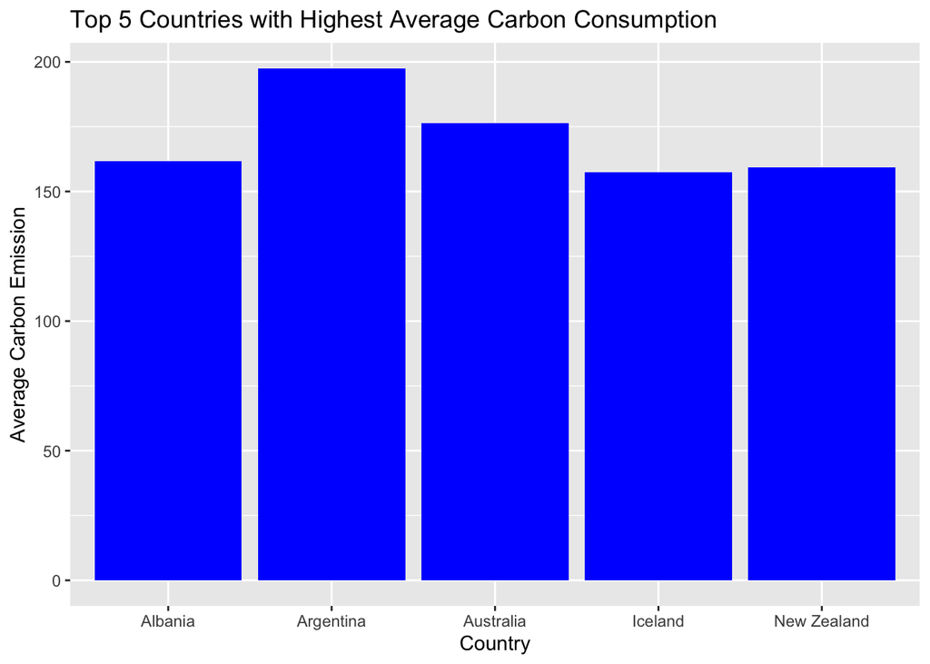

```r
#Grouped the data by country and calculated the average carbon emission
country_carbon <- food_consumption %>%
  group_by(country) %>%
  summarise(avg_carbon = mean(co2_emmission)) %>%
  arrange(desc(avg_carbon)) %>%
  head(5)

#Created a bar plot of the top 5 countries with the highest average carbon consumption
ggplot(country_carbon, aes(x = country, y = avg_carbon)) +
  geom_bar(stat = "identity", fill = "blue") +
  ggtitle("Top 5 Countries with Highest Average Carbon Consumption") +
  xlab("Country") +
  ylab("Average Carbon Emission")
```

##### Graph 1: Top 5 Countries with Highest Average Carbon Consumption

- In this first graph, I used a bar plot to look at the 5 countries with the highest Carbon consumption. I was very interested to see that Albania and Argentina are some of the countries with the greatest output. In terms of population, Australia (25.69 million) and Argentina (45.81) definitely have large populations but Albania only has a population of 2.81 million which really made me wonder why they had such a large output and ranked third with such a small amount of people.

```r
# Filtered the data to only include data for Uruguay
uruguay_data <- food_consumption %>%
  filter(country == "Uruguay")

# Calculated the total carbon emissions by food category in Uruguay
uruguay_carbon <- uruguay_data %>%
  group_by(country, food_category) %>%
  summarise(total_emissions = sum(co2_emmission))
```

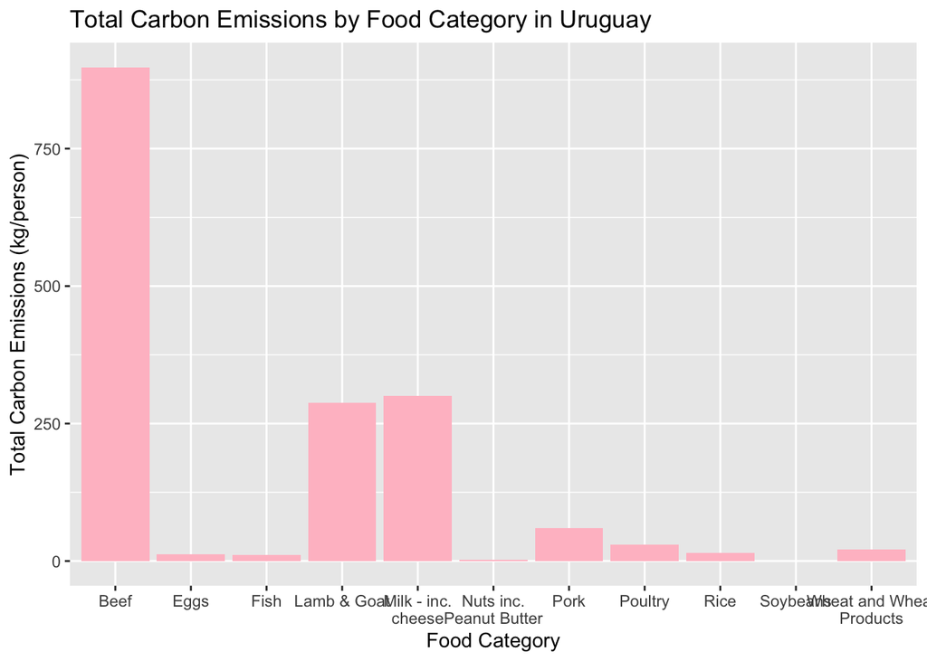

```r
# Created a bar plot of the total carbon emissions by food category in Uruguay
ggplot(uruguay_carbon, aes(x = str_wrap(food_category, width = 15), y = total_emissions)) +
  geom_bar(stat = "identity", fill = "pink") +
  ggtitle("Total Carbon Emissions by Food Category in Uruguay") +
  xlab("Food Category") +
  ylab("Total Carbon Emissions (kg/person)")
```

##### Graph 2: Total Carbon Emissions by Food Category in Uruguay

- In this bar graph, we are individually looking at the different food categories within the country of Uruguay. As I had hypothesized, the carbon emission from beef is much higher compared to our other foods. Red meat is a big staple in Uruguayan Culture, so I am not surprised to see that lamb and goat have the third highest ranked category whereas as areas like poultry, pork, and fish are much lower and almost total to nothing compared to our red meat categories. The second highest category is cheese and we eat our meat with cheese on top of it, so again, this is very expected of Uruguay.

```r
# Filtered the data to only include data for Argentina
argentina_data <- food_consumption %>%
  filter(country == "Argentina")

# Calculated the total carbon emission by food category in Argentina
argentina_carbon <- argentina_data %>%
  group_by(country, food_category) %>%
  summarise(total_emissions = sum(co2_emmission))
```

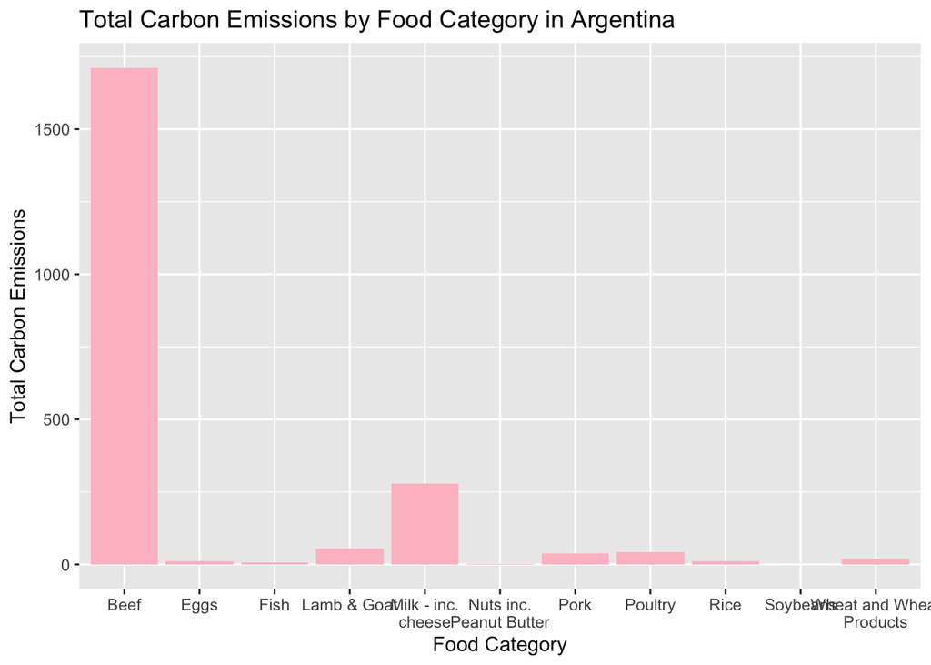

```r
# Created a bar plot of the total carbon emissions by food category in Argentina
ggplot(argentina_carbon, aes(x = str_wrap(food_category, width = 15), y = total_emissions)) +
  geom_bar(stat = "identity", fill = "pink") +
  ggtitle("Total Carbon Emissions by Food Category in Argentina") +
  xlab("Food Category") +
  ylab("Total Carbon Emissions")
```

##### Graph 3: Total Carbon Emissions by Food Category in Argentina

- Just like Uruguay, I expected for Argentina to have a large carbon emission output in terms of red meat. I’m very surprised to see that beef is actually not higher than what it is becuase Argentina’s population if almost more than ten fold that of Uruguay, so that really puts everything into perspective in terms of how much meat Uruguayans eat.

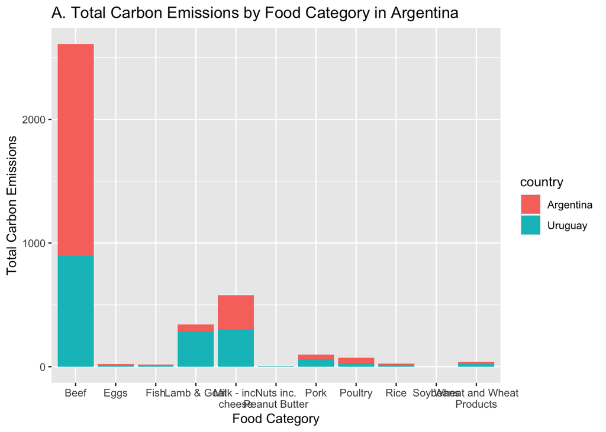

```r
ggplot(bind_rows(uruguay_carbon, argentina_carbon), aes(x = str_wrap(food_category, width = 15), y = total_emissions, fill = country )) +
  geom_bar(stat = "identity") +
  ggtitle("A. Total Carbon Emissions by Food Category in Argentina") +
  xlab("Food Category") +
  ylab("Total Carbon Emissions")
```

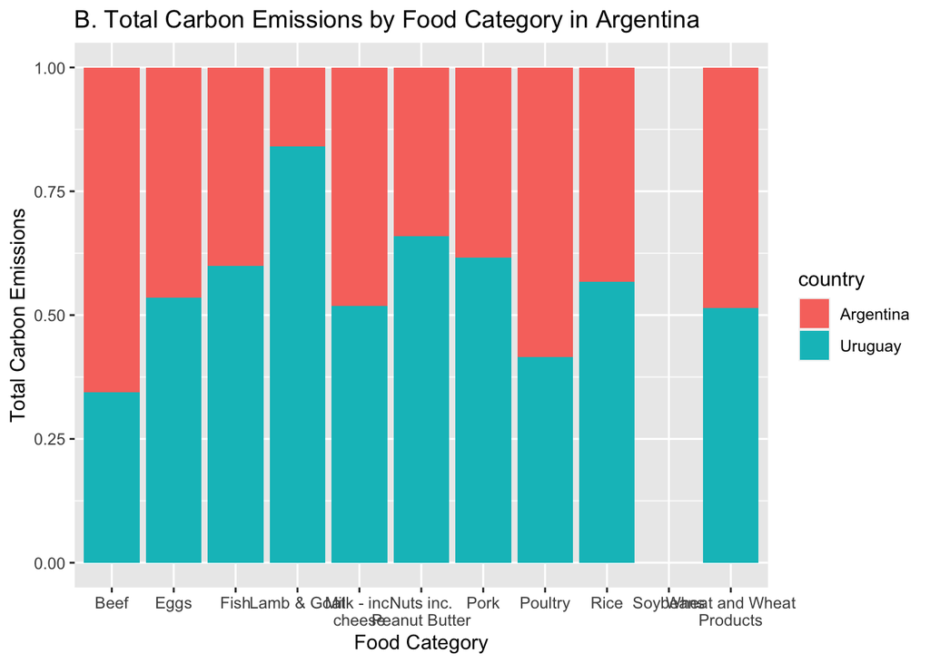

```r
ggplot(bind_rows(uruguay_carbon, argentina_carbon), aes(x = str_wrap(food_category, width = 15), y = total_emissions, fill = country )) +
  geom_bar(stat = "identity", position = "fill") +
  ggtitle("B. Total Carbon Emissions by Food Category in Argentina") +
  xlab("Food Category") +
  ylab("Total Carbon Emissions")
```

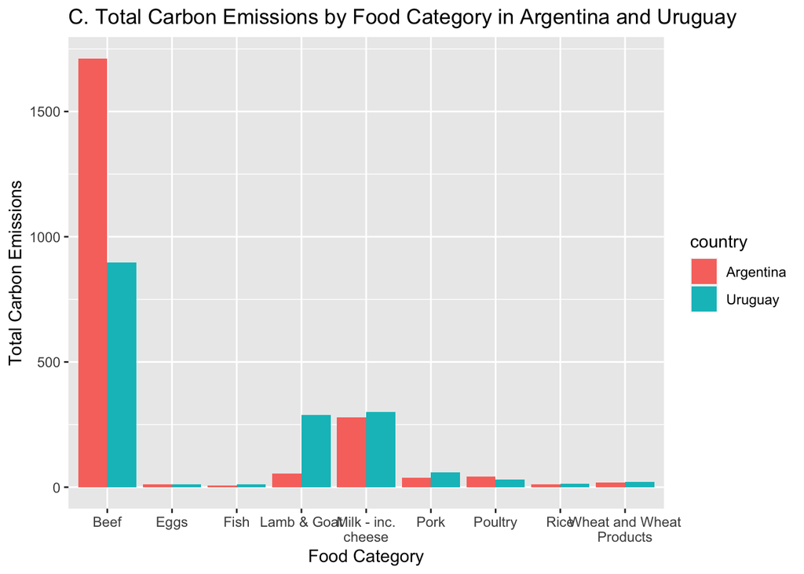

```r
ggplot(bind_rows(uruguay_carbon, argentina_carbon) %>%
         filter(!(food_category %in% c("Soybeans", "Nuts inc. Peanut Butter"))), aes(x = str_wrap(food_category, width = 15), y = total_emissions, fill = country )) +
  geom_bar(stat = "identity", position = "dodge") +
  ggtitle("C. Total Carbon Emissions by Food Category in Argentina and Uruguay") +
  xlab("Food Category") +
  ylab("Total Carbon Emissions")
```

##### Graph 4A, 4B, 4C: Total Carbon Emissions by Food Category in Argentina and Uruguay

- Here, I have three different sets of code that are three different ways to look at the same information. I just wanted to put the numbers of these categories side by side per country to really look at them. All three graphs are bar graphs but differ in presentation through elements like “position” where I used “fill” and “dodge” to make them look much different but still hold the same information.

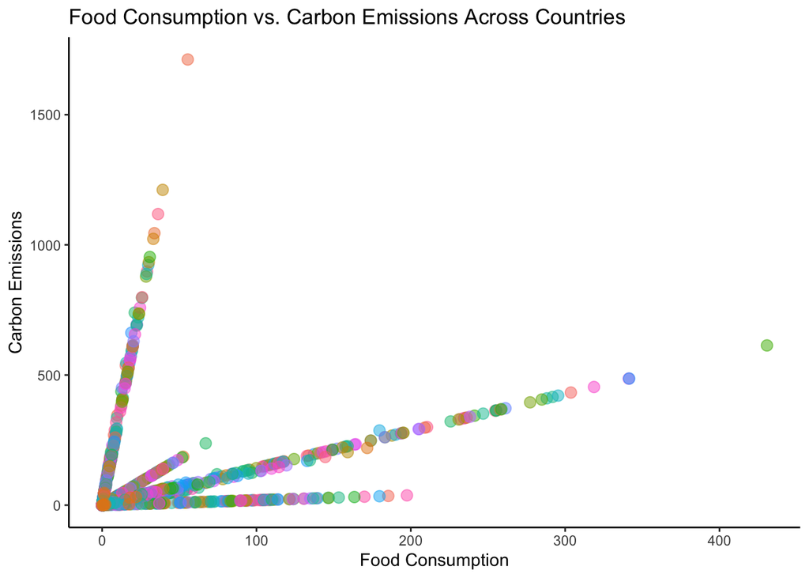

```r
ggplot(food_consumption, aes(x = consumption, y = co2_emmission, color = country)) +
  geom_point(alpha = 0.5, size = 3, show.legend = FALSE) +
  ggtitle("Food Consumption vs. Carbon Emissions Across Countries") +
  xlab("Food Consumption") +
  ylab("Carbon Emissions") +
  theme_classic()
```

##### Graph 5: Food Consumption vs. Carbon Emissions Across Countries

- We do not have a legend here to show which color is which country because it would break my laptop if I did, but I thought that using this scatterplot would help look at the correlation between food consumption and carbon emission. I originally hypothesized that countries with higher food consumption would emit larger amounts of carbon, but, as we can see, there seem to be four different lines within this graph that all follow a trend. I would be curious to see where these countries reside and if there is correlation in terms of region or continent which could explain their similarity. I was very surprised by that first, more largely angled line because this shows that some countries with the lowest food consumption actually ended up having the highest amount of carbon emission.

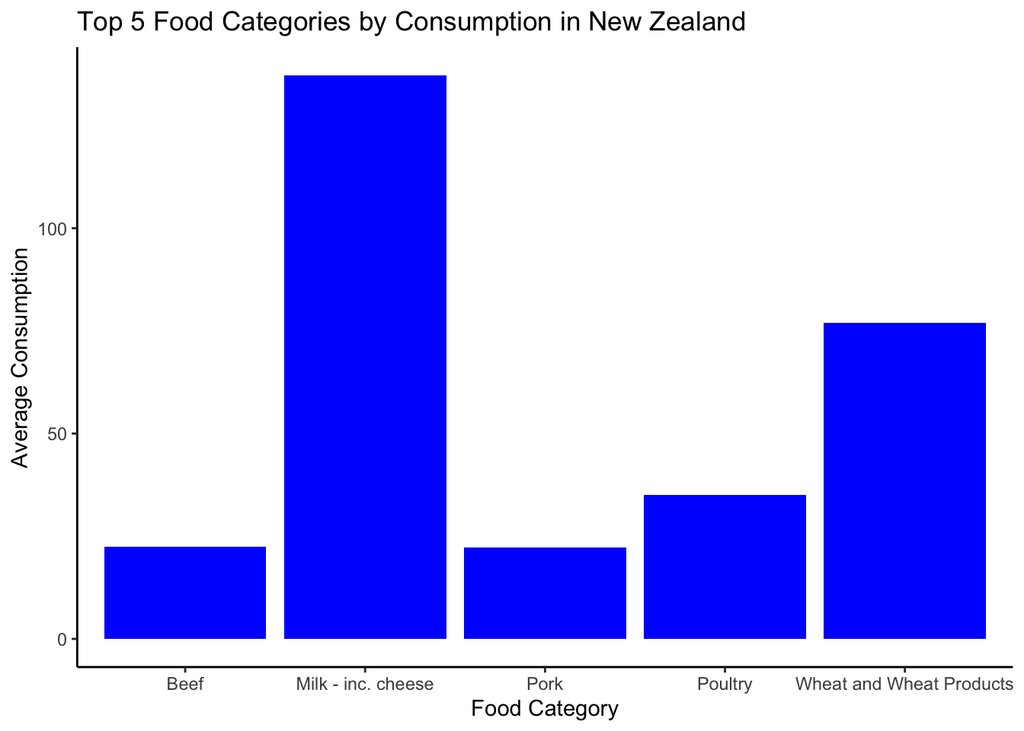

```r
# here, I filtered data for New Zealand only
nz_consumption <- food_consumption %>%
  filter(country == "New Zealand")

# group by food category and calculate average consumption
nz_food_consumption <- nz_consumption %>%
  group_by(food_category) %>%
  summarize(avg_consumption = mean(consumption)) %>%
  top_n(5, avg_consumption) %>%
  arrange(desc(avg_consumption))

# plot the bar chart
ggplot(nz_food_consumption, aes(x = food_category, y = avg_consumption)) +
  geom_bar(stat = "identity", fill = "blue") +
  ggtitle("Top 5 Food Categories by Consumption in New Zealand") +
  xlab("Food Category") +
  ylab("Average Consumption") +
  theme_classic()
```

##### Graph 6: Top 5 Food Categories by Consumption in New Zealand

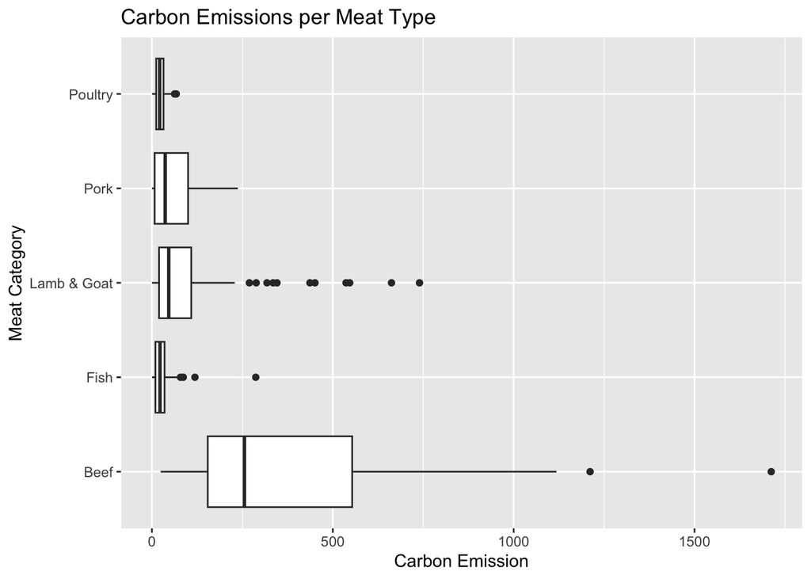

```r
# Trying to group food categories together to find overall emission from different meats
food_consumption %>%
  filter(food_category %in% c("Pork", "Beef", "Poultry", "Lamb & Goat", "Fish"))%>%
  group_by(food_category) %>%
  ggplot() +
  ggtitle("Carbon Emissions per Meat Type") +
  xlab("Carbon Emission") +
  ylab("Meat Category") +
  geom_boxplot(aes(y= food_category, x = co2_emmission))
```

##### Graph 7: Carbon Emissions per Meat Type

- Lastly, I wanted to more closely look at carbon emission per meat type. Here, I used a boxplot to help conceptualize the data and see what averages were and how it was distributed among all of the information. For years, professionals have been saying that the consumption of meat produces a large amount of carbon but I never fully understood that until looking at this graph. It is very interesting to see how the carbon emission from categories like poultry and fish is so minor compared to that of the other ones. I think that showing this type of graph to more people would impact how they ate a bit more.